# Colorspace in R - Getting Started

Alec Jacobs

September 26, 2023

Reproducible Vignette - Communication In Urban Spatial Analytics | 09.26.2023 | Alec Jacobs

### Abstract

The **colorspace** package in R provides a flexible toolbox for selecting individual colors or palettes, and enables color manipulation for statistical graphics or data visualizations. In particular, **colorspace** provides a broad range of color palettes based on the color space model of HCL - Hue, Chroma, Luminance. The three HCL dimensions match the human visual system well, thus facilitating intuitive selection of color palettes through trajectories of visual space.

### Introduction

Color plays a crucial role in statistical graphics and data visualizations. As a result, it is essential to select colors thoughtfully to ensure that all viewers can easily access the presented information. Currently, many software packages provide only color palettes derived with simple RGB color combinations, which have poor perceptual properties. Color visualizing statistical packages have been emerging to ultimately provide better perceptual quality including the packages ColorBrewer, Viridis, RCartoColor, WesAnderson, Pals, and Paleteer. These packages/palettes, however, are still limited in color selection.

As a palette alternative, the **colorspace** package derives general and adaptable strategies for color palettes; manipulates individual colors and color palettes; and assesses or visualizes the properties of color palettes. Central to the package is the various utilities for computing with color spaces, which supports the mapping of three-dimensional representations of color to one another. A particularly important mapping is the one from the perceptually-based and device-independent color model HCL to standard RGB - the basis for color specifications in many systems based on the corresponding hex codes.

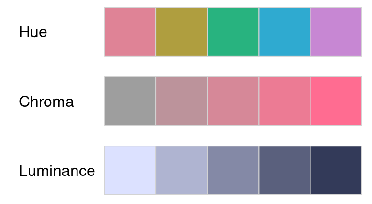

The HCL space is particularly useful for specifying individual colors and color palettes as its three axes match those of the human visual system well: Hue (= type of color, dominant wavelength), Chroma (= colorfulness), Luminance (= brightness). The three palettes based on the HCL model provided by **colorspace** are as follows:

• Qualitative: Designed for coding categorical information, i.e., where no particular ordering of categories is available and every color should receive the same perceptual weight. The function is qualitative_hcl().

• Sequential: Designed for coding ordered/numeric information, i.e., where colors go from high to low (or vice versa). The function is sequential_hcl().

• Diverging: Designed for coding ordered/numeric information around a central neutral value, i.e., where colors diverge from neutral to two extremes. The function is diverging_hcl().

### Installation

```r
install.packages("colorspace", repos = "https://R-Forge.R-project.org")
```

The development version of **colorspace** is hosted on R-Forge in a Subversion (SVN) Repository. Run the following code to install the development version.

```r
install.packages("colorspace", repos = "https://R-Forge.R-project.org")
```

If you’ve already installed **colorspace**, load the following in your current session of R.

```r
library("colorspace")
```

### Choosing Color Palettes Based On HCL

The **colorspace** package ships with a wide range of predefined color palettes, specified through suitable trajectories in the color space of HCL. The functions sequential_hcl(), and diverging_hcl() work analogously. Additionally, their hue/chroma/luminance parameters can be modified, thus allowing for easy customization of each palette. Moreover, the choose_palette()/hclwizard() app provide convenient user interfaces to perform palette customization interactively. Finally, even more flexible diverging HCL palettes are provided by divergingx_hcl(). A quick overview can be gained easily with the hcl_palettes() function below:

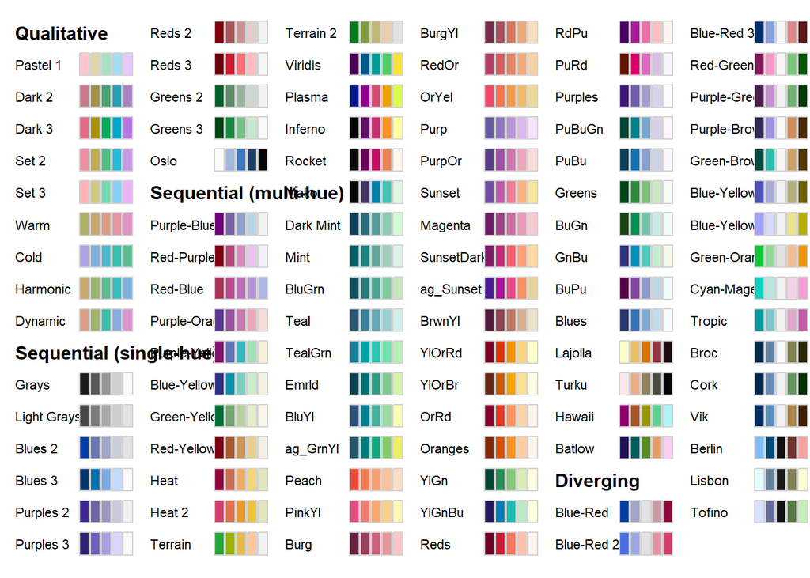

```r
library("colorspace")
hcl_palettes(plot = TRUE)
```

A suitable vector of colors can be easily computed by specifying the desired number of colors and the palette name. See the plot above.

```r
q4 <- qualitative_hcl(4, palette = "Dark 3")
q4
```

```
## [1] "#E16A86" "#909800" "#00AD9A" "#9183E6"
```

### Usage: Base Graphics

The color vectors returned by the HCL palette functions can usually be passed directly to most base graphics, typically through the “col” argument. Here, the q4 vector created above is used in a time series display:

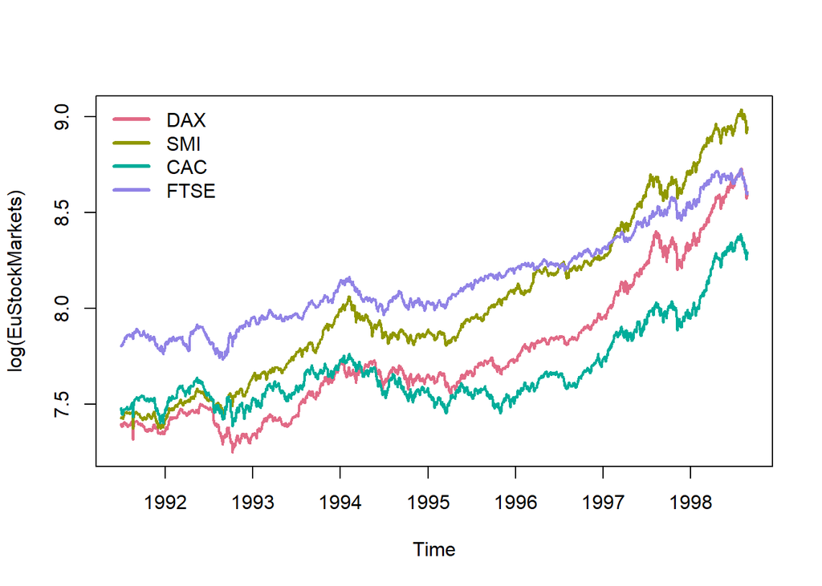

```r
plot(log(EuStockMarkets), plot.type = "single", col = q4, lwd = 2)
legend("topleft", colnames(EuStockMarkets), col = q4, lwd = 3, bty = "n")
```

### Usage: GGPLOT

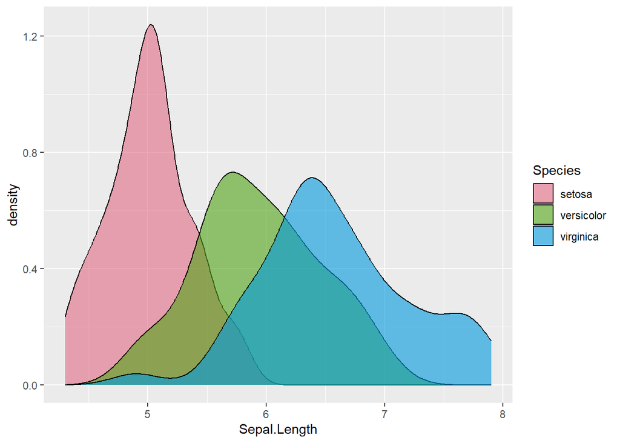

```r
library("ggplot2")
ggplot(iris, aes(x = Sepal.Length, fill = Species)) + geom_density(alpha = 0.6) +
  scale_fill_discrete_qualitative(palette = "Dark 3")
```

### Palette Visualization and Assessment

The colorspace package also provides a number of functions that aid visualization and assessment of its palettes.

• demoplot() can display a palette (with arbitrary number of colors) in a range of typical and somewhat simplified statistical graphics.

• hclplot() converts the colors of a palette to the corresponding hue/chroma/luminance coordinates and displays them in HCL space with one dimension collapsed. The collapsed dimension is the luminance for qualitative palettes and the hue for sequential/diverging palettes.

• specplot() also converts the colors to hue/chroma/luminance coordinates but draws the resulting spectrum in a line plot.

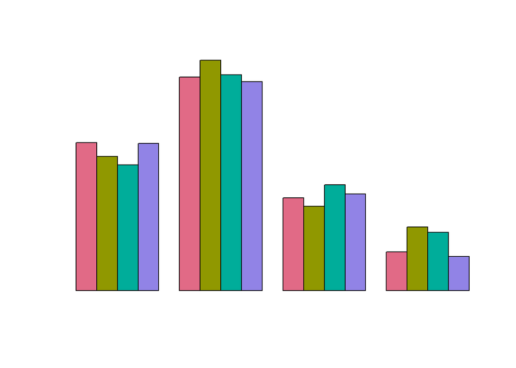

```r
demoplot(q4, "bar")
```

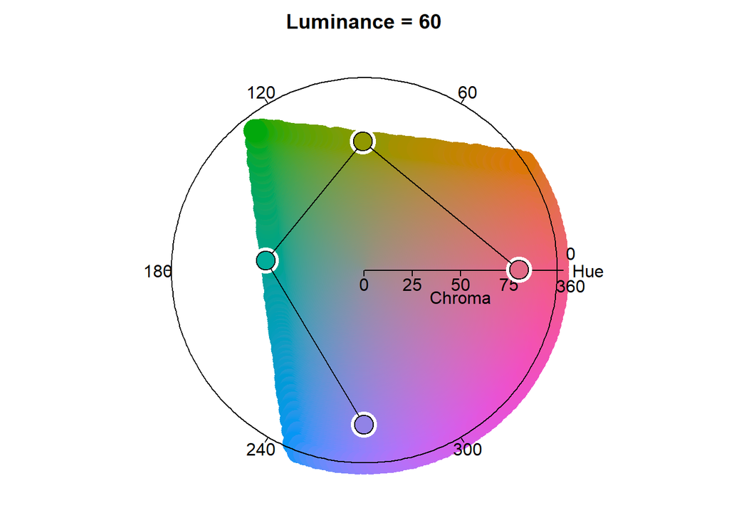

```r
hclplot(q4)
```

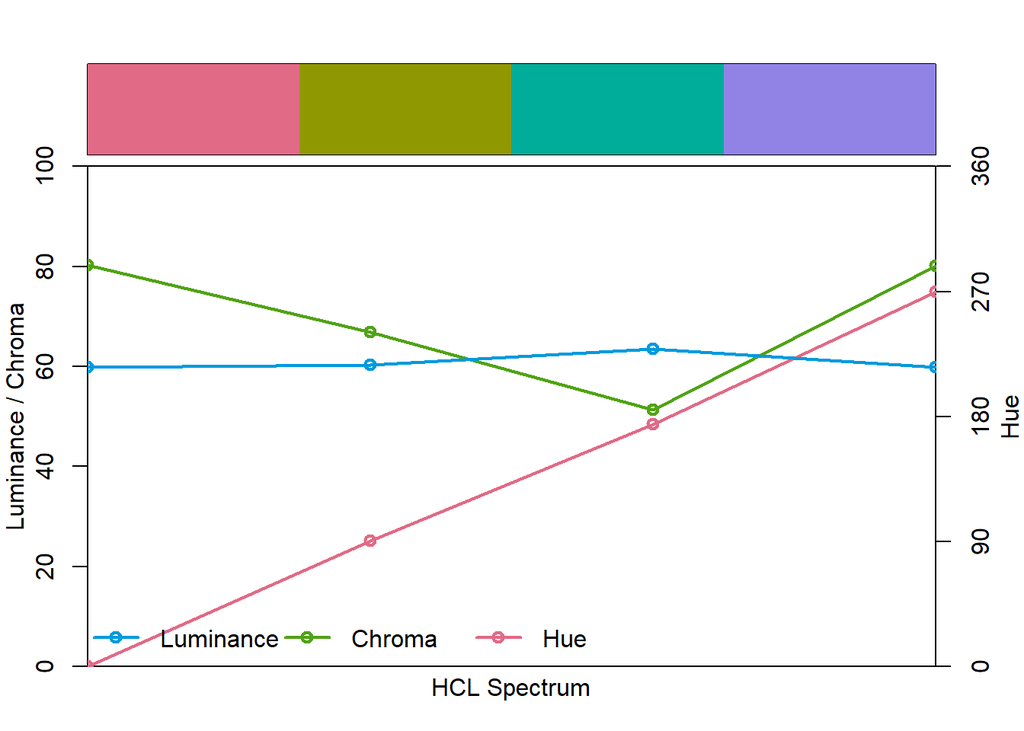

```r
specplot(q4, type = "o")
```

The bar plot is used as a typical application for a qualitative palette (in addition to the time series and density plots used above). The other two displays show that luminance is (almost) constant in the palette while the hue changes linearly along the color “wheel”. Ideally, chroma would have also been constant to completely balance the colors. However, at this luminance the maximum chroma differs across hues so that the palette is fixed up to use less chroma for the yellow and green elements.

### Conclusion

In summary, this tutorial provided a high-level overview of **colorspace** - a package in R providing flexible toolbox for selecting individual colors or palettes, and enabling color manipulation for statistical graphics and data visualizations. Further, this package provides various qualitative, sequential, and diverging palettes derived by relatively simple trajectories in the visual space of HCL. In contrast to many other packages providing modern balanced color palettes, special emphasis is given to flexibility of the palettes which can be adjusted to the particular needs of a given data visualization.

### Additional Resources

For more detailed overviews and examples, visit the following listed resources: [Color Spaces: S4 Classes and Utilities](https://colorspace.r-forge.r-project.org/articles/color_spaces.html); [HCL-Based Color Palettes](https://colorspace.r-forge.r-project.org/articles/hcl_palettes.html); [HCL-Based Color Scales for ggplot2](https://colorspace.r-forge.r-project.org/articles/ggplot2_color_scales.html); [Palette Visualization and Assessment](https://colorspace.r-forge.r-project.org/articles/palette_visualization.html); [Apps for Choosing Colors and Palettes Interactively](https://colorspace.r-forge.r-project.org/articles/hclwizard.html), [Color Vision Deficiency Emulation](https://colorspace.r-forge.r-project.org/articles/color_vision_deficiency.html); [Color Manipulation and Utilities](https://colorspace.r-forge.r-project.org/articles/manipulation_utilities.html); [Approximating Palettes from Other Packages](https://colorspace.r-forge.r-project.org/articles/approximations.html); [Somewhere Over The Rainbow](https://colorspace.r-forge.r-project.org/articles/endrainbow.html). Visit this Journal of Statistical Software article for a complete detailed overview: [Colorspace: A Toolbox for Manipulating and Assessing Colors and Palettes](https://www.jstatsoft.org/article/view/v096i01).